# Abstract

# Wind Potential in the Red Sea

Offshore wind resource in Saudi Arabia has not been studied due to lack of data. Current studies are limited to onshore coastal sites where there are meteorological stations [@rehman_assessment_2004]. In this study we used simulation results to assess high potential locations for offshore wind farms in the Red Sea. This approach has been studied and validated in an offshore wind study off the Californian coast [@dvorak_california_2010].

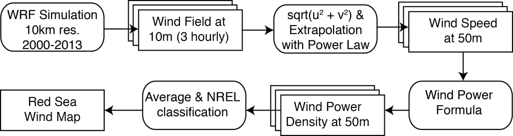

# Best Regions for Offshore Wind

We selected three regions with the best wind potential.

- Site A: Entrance to Gulf of Aqaba
- Site B: West of Yanbu
- Site C: South of Jeddah

We performed a time series analysis on average capacity factor (CF), percentage of theoretical maximum capacity, based on a [Siemens SWT3.6MW-107m](http://www.energy.siemens.com/hq/en/renewable-energy/wind-power/platforms/g4-platform/wind-turbine-swt-3-6-107.htm) turbine.

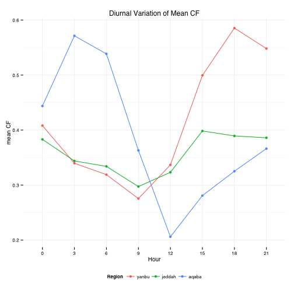

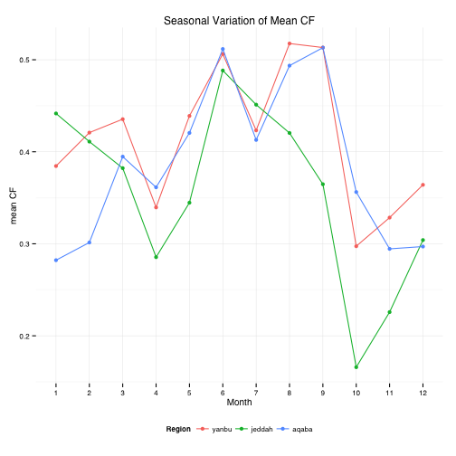

The three sites have their peak production during the summer, when the demand for energy is the highest in Saudi Arabia. The resource is the highest in the afternoon and the evening, except for Site A, which peaks during the night.

# Wind Farming the Red Sea?

## Future works

- On site validation at the identified sites
- Study of grid integration
- Sea bed characterization
- Evaluation of the cost with higher accuracy
- Quantification of environmental benefits